# 2008-2014年自來水用水量統計分析

謝青恩

2017年1月23日

**使用R的Base plotting system繪製分析圖表。**

## **資料簡介**

- **資料集名稱**：自來水生活用水量統計
- **資料來源**：行政院環境保護署
- **資料發布時間**：105年9月13日
- **資料欄位**：統計年度(Year)、縣市別(ExecutingUnit)、生活用水量(TheDomesticConsumptionOfWater)、年中供水人數(PopulationServed)、每人每日生活用水量(TheDailyDomesticConsumptionOfWaterPerPerson)、備註(Remarks)
- **資料內容**：2008年至2014年各縣市的自來水用水量統計

```
##         Year ExecutingUnit DomesticConsumptionWater PopulationServed
## 1 2014/12/31        澎湖縣                  7581201            94295
## 2 2014/12/31        臺南市                174298049          1864431
## 3 2014/12/31        臺東縣                 16648480           177790
## 4 2014/12/31        臺北市                327020637          2687780
## 5 2014/12/31        臺中市                253403867          2541593
##   DailyWaterPerPerson Remarks
## 1                 220      無
## 2                 256      無
## 3                 257      無
## 4                 333      無
## 5                 273      無
```

## **每人每日用水量**

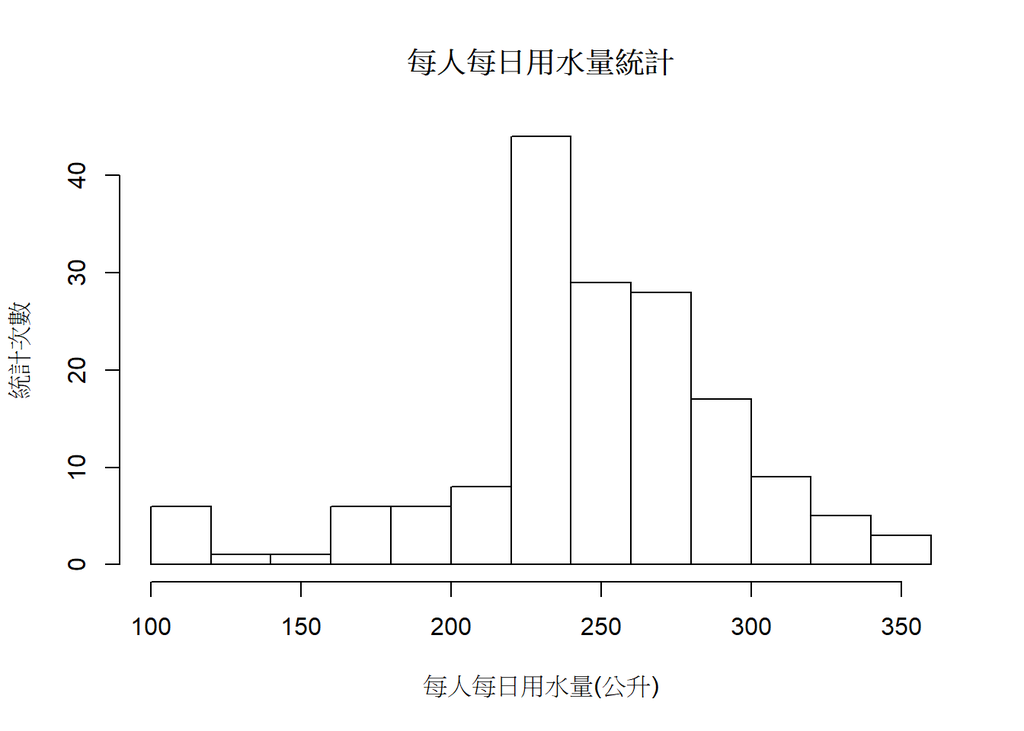

1996年至2014年平均每人每日用水量逐漸下降且趨於平緩，近年主要落在250公升左右。

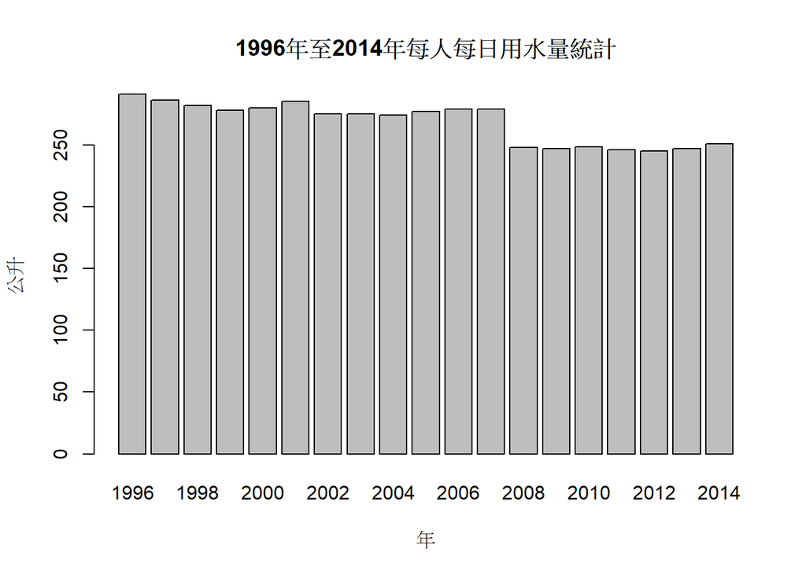

## **六個直轄市生活用水量比較**

發現臺北市的人用水比較兇。而臺中市的人民在這七年間平均生活用水量變化幅度甚大， 可以進一步篩選出來觀察看看。

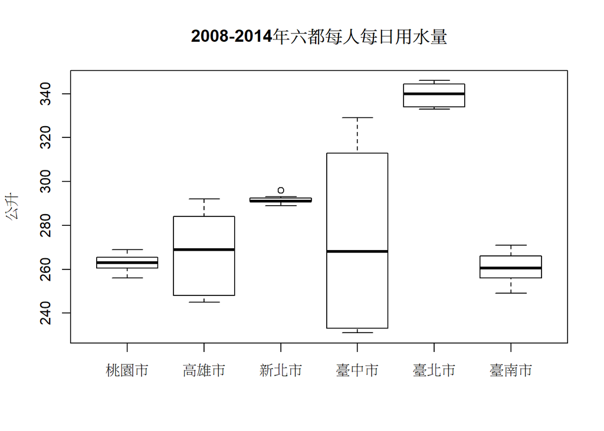

臺北市人民用水量雖然居高但是有逐年省水的情形。 臺中市人民的用水量突然在2011年大幅下降。

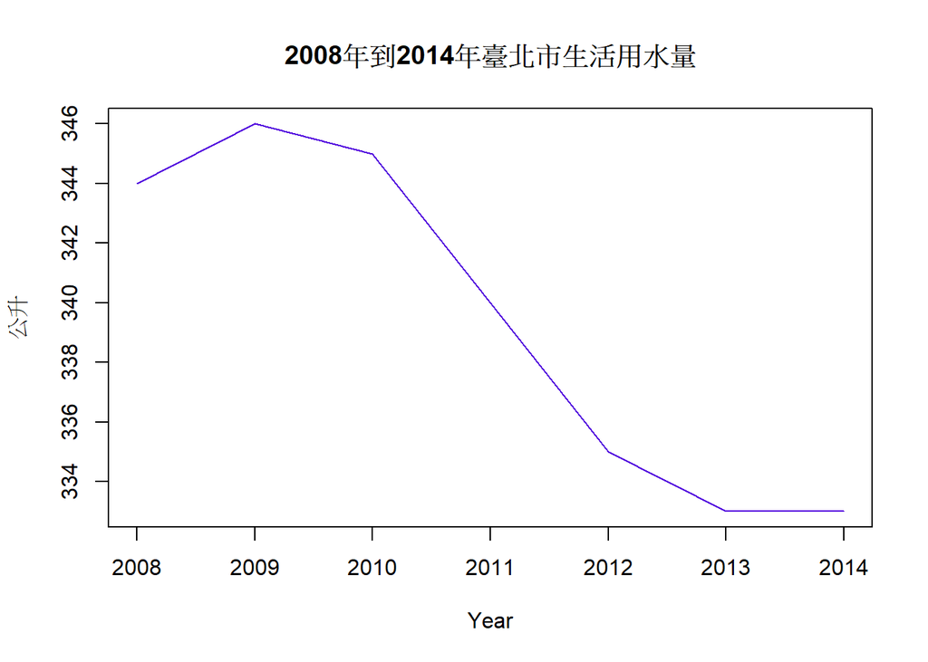

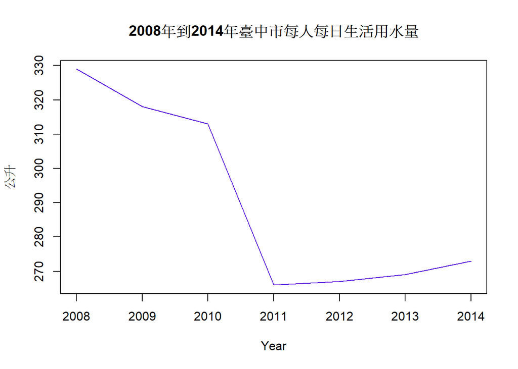

用散佈圖來看各年度各縣市不同的自來水供給人口數和人均用水量，看不出什麼明顯的趨勢。

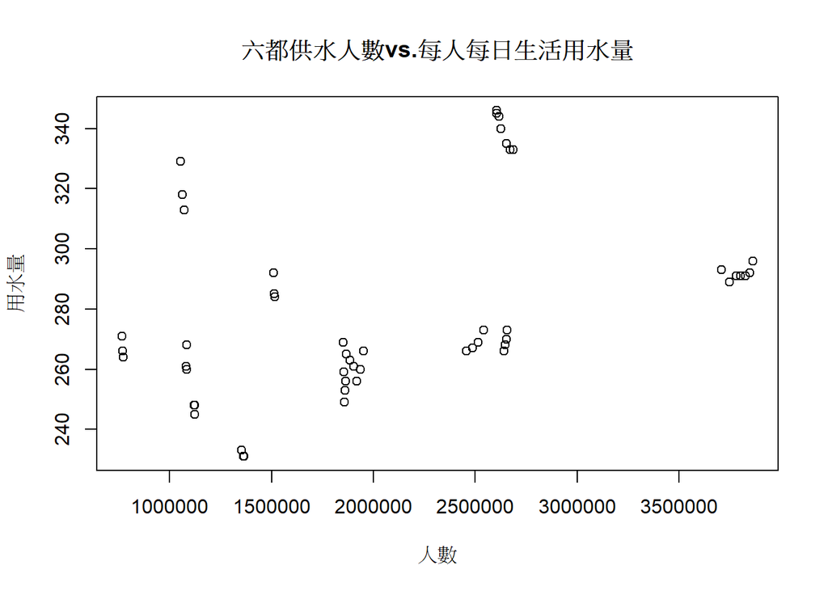